# Project Phase 2: Preliminary Model Results

Author

Kyle Lew, Andriy Uspishnyi, Ben Laufer, Roee Morag, Tim Christian

### Libraray imports and data setup

```python
import warnings
from sklearn.exceptions import ConvergenceWarning

warnings.filterwarnings('ignore', category=ConvergenceWarning)
```

```python
import pandas as pd
import numpy as np
from sklearn.pipeline import Pipeline
from sklearn.preprocessing import StandardScaler, OneHotEncoder, PolynomialFeatures
from sklearn.linear_model import LinearRegression, Ridge, Lasso, ElasticNet
from sklearn.model_selection import train_test_split
from sklearn.metrics import r2_score
from sklearn.compose import ColumnTransformer
from sklearn.metrics import mean_squared_error
from sklearn.model_selection import cross_val_score
from sklearn.model_selection import GridSearchCV
from sklearn.compose import make_column_selector, ColumnTransformer
from plotnine import *
import warnings
from sklearn.neighbors import KNeighborsRegressor

from plotnine import ggplot, aes, geom_boxplot, scale_x_discrete, guides, theme_classic, labs, geom_point
```

```python
df = pd.read_csv("/Users/lewk20/Desktop/MSBA/GSB_544/544_Project/filtered_data.csv")

# Fix dtypes
df["insert_date"] = pd.to_datetime(df["insert_date"])
df["start_date"] = pd.to_datetime(df["start_date"])
df["end_date"] = pd.to_datetime(df["end_date"])
```

```python
df.dtypes
```

```
Unnamed: 0              int64
insert_date    datetime64[ns]
origin                 object
destination            object
start_date     datetime64[ns]
end_date       datetime64[ns]
price                 float64
train_class            object
fare                   object
Duration               object
day_of_week            object
time_of_day            object
dtype: object
```

```python
df.head()
```

|  | Unnamed: 0 | insert_date | origin | destination | start_date | end_date | price | train_class | fare | Duration | day_of_week | time_of_day |
| --- | --- | --- | --- | --- | --- | --- | --- | --- | --- | --- | --- | --- |
| 0 | 1 | 2019-04-19 05:31:43 | MADRID | SEVILLA | 2019-05-29 07:00:00 | 2019-05-29 09:32:00 | 53.4 | Turista | Promo | 0 days 02:32:00 | Wednesday | Morning |
| 1 | 2 | 2019-04-19 05:31:43 | MADRID | SEVILLA | 2019-05-29 07:30:00 | 2019-05-29 09:51:00 | 47.3 | Turista | Promo | 0 days 02:21:00 | Wednesday | Morning |
| 2 | 3 | 2019-04-19 05:31:43 | MADRID | SEVILLA | 2019-05-29 08:00:00 | 2019-05-29 10:32:00 | 69.4 | Preferente | Promo | 0 days 02:32:00 | Wednesday | Morning |
| 3 | 5 | 2019-04-19 05:31:43 | MADRID | SEVILLA | 2019-05-29 09:00:00 | 2019-05-29 11:38:00 | 60.3 | Turista | Promo | 0 days 02:38:00 | Wednesday | Morning |
| 4 | 7 | 2019-04-19 05:31:43 | MADRID | SEVILLA | 2019-05-29 10:00:00 | 2019-05-29 12:32:00 | 47.3 | Turista | Promo | 0 days 02:32:00 | Wednesday | Morning |

# Data Summary

**Background**

This dataset is composed of Renfe tickets, Spain’s nation’s state-owned railway company. A [link](https://www.kaggle.com/code/mjella45/spanish-high-speed-rail-tickets-pricing/input) to this dataset can be found here. Between 2019-04-11 and 2019-05-09 extensive data was collected for every train ticket that was purchased.

It is important to note that only tickets whose train types were “AVE” will now be used in this analysis. In order to be able to effectively apply the results of our models to our research questions it is important that we have consistent train speeds/types. As a result the train type variable is no longer useful in our analysis. Thankfully this removal of observations costs less than 10% of the data (still have over 1.5 million observations).

**Renfe Train Ticket Variables**

- Insert_date (Date and time ticket was purchased) // drop tickets from outside of trip range
- Origin (City)
- Destination (City)
- Trip End (Date and time)
  - Redundant to use as a variable in modeling, but was used to derive the trip duration variable
- Ticket Price (in $)
- Ticket Class: Level of comfort and amenities provided during the journey
  - Turista
    - Cheapest ticket- standard seating Turista Plus
    - Upgraded option in the Turista class; providing a more spacious seating arrangement
  - Turista con enlace
    - Turista ticket that includes connections across different train types
  - Cama Turista
    - Sleeping arrangement on night trains, providing a bed in shared compartments
  - Preferente
    - “First-class” option that offers a higher level of comfort, more personal space, and additional perks
- Ticket Fare: Determines the ticket’s flexibility, refund policy, and additional perks regardless of the class
  - Promo
    - Lowest-cost option and come with significant discounts
  - Flexible
    - Offers maximum flexibility in terms of changes and cancellations
  - Adulto Ida
    - “One-Way Adult” and is the standard one-way fare for an adult
  - Promo +
    - Offers a balance between affordability and flexibility
  - Individual-Flexible
    - Flexible fare tailored for individual travelers

**Derived variables(Feature Engineering)** - Duration (end_time - start_time) - Day of Week (derived from start_time) - Time of Day (Categorical) (derived from original variable “start_time”) - Morning - Trains departing between 5am and 12pm - Afternoon - Trains departing between 12pm and 5pm - Evening - Trains departing between 5pm and 11pm - Night - Trains departing between 11pm and 5am

**Location Dataset Variables(web scraping from this [website](https://livingcost.org/cost/spain/valencia))**

- Cost of Living (from train origin)
  - Web scrape
  - Will be done for each city that has currently has an AVE train station as well as new cities that we want to try to predict fair ticket prices
- Cost of Living (from train destination)
  - Web scrape
  - Will be done for each city that has currently has an AVE train station as well as new cities that we want to try to predict fair ticket prices
- Duration
  - How long it will take to get from one station to another
  - Need to do for ONLY each new city (as we already have already derived trip duration from stations that already exist)
  - Will calculate using distance and speed of train (which is now consistent due to having one train type)
  - Will get distance information from maps/manually entering data

### Summary Visualization 1

```python
df["day_of_week"] = pd.Categorical(df["day_of_week"], categories=["Monday", "Tuesday",
"Wednesday", "Thursday", "Friday", "Saturday", "Sunday"], ordered=True)
```

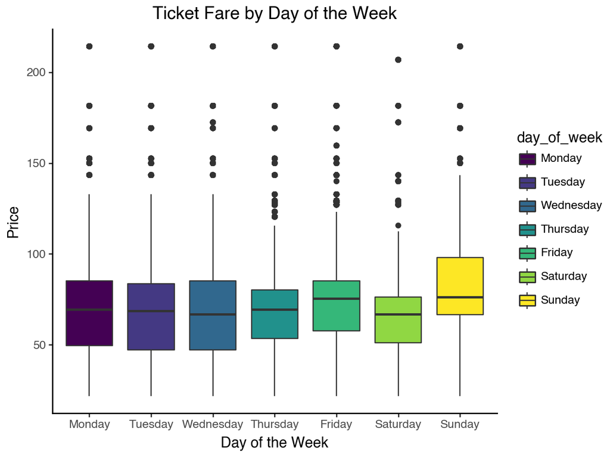

```python
(ggplot(df,
aes(x = "day_of_week", y = "price", fill="day_of_week"))
+ geom_boxplot()
+ theme_classic()
+ scale_x_discrete()
+ guides(fill=None)
+ labs(x="Day of the Week", y="Price", title="Ticket Fare by Day of the Week")
)
```

Day of the week seems instrumental in predicting the ticket fare, particularly looking at ticket fares on Sunday. Any pricing plan that SMART intends to use for a new train station should factor in higher ticket prices on Sunday.

### Summary Visualization 2

```python
df["Duration"].str[7:]

df["Duration (minutes)"] = pd.to_timedelta(df["Duration"]).dt.total_seconds() / 60
```

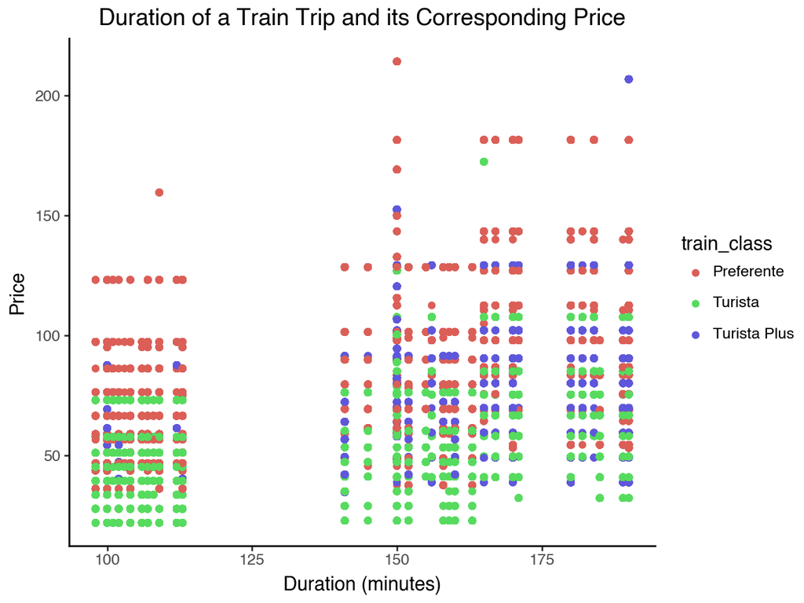

```python
(ggplot(df,
aes(x = "Duration (minutes)", y = "price", color="train_class"))
+ geom_point()
+ theme_classic()
+ labs(x="Duration (minutes)", y="Price", title="Duration of a Train Trip and its Corresponding Price")
)
```

We were expecting duration to be highly correlated with the pricing of a train ticket. The results in this visualization were incredibly surprising to us. Even with train rides differing in durations by up to an hour, their pricing doesn’t rise accordingly. We will explore this more in the next phase with demographic data, but we do believe that Ticket Class (Preferential, Tourist, etc.) and the actual destination are more important to predicting pricing. Not shown in this visualization, buy tickets to Barcelona are the most expensive, which could be corroborated by cost of living and population predictor variables.

As for train class, Turista tickets cost less and Preferential tickets cost more, as expected, and those are more important to predicting the price of any random ticket than the actual duration of the trip.

# Research Questions and Models

### Model Prep

```python
X = df.drop(columns=['Unnamed: 0', 'insert_date', 'start_date', 'end_date', 'price', 'Duration'], axis=1)
y = df['price']

ct = ColumnTransformer(
  [
    ("dummify", OneHotEncoder(sparse_output = True, handle_unknown='ignore', drop='first'), make_column_selector(dtype_include=object)),
    ("standardize", StandardScaler(), make_column_selector(dtype_include=np.number))
  ],
  remainder = "drop"
)
```

## RQ1: Can a machine learning model be developed to accurately predict train ticket fare costs in Spain, providing customers with reliable fare estimates for future travel planning?

### Model 1: Elastic Net

**Predictors:**

**Preprocessing**

- Standardize quantitative variables
- Dummify categorical variables

**Tuning**

- alpha: (0.01, 0.1, 1, 10)
- L1: (0, 0.25, 0.5, 0.75, 1)

**Metric**

- R2 score

```python
pipeline = Pipeline(
  [("preprocessing", ct),
  ("elastic_net", ElasticNet())]
)

params = {
    'elastic_net__alpha': [0.01, 0.1, 1, 10],
    'elastic_net__l1_ratio': [0, 0.25, 0.5, 0.75, 1]
    }

gscv = GridSearchCV(pipeline, params, cv = 5, scoring='r2')

gscv_fitted = gscv.fit(X, y)

params_df = pd.DataFrame(gscv_fitted.cv_results_["params"])
results_df1 = params_df.assign(scores=gscv_fitted.cv_results_["mean_test_score"])
```

```python
results_df1.sort_values(by="scores", ascending=False).head()
```

|  | elastic_net__alpha | elastic_net__l1_ratio | scores |
| --- | --- | --- | --- |
| 4 | 0.01 | 1.00 | 0.767045 |
| 3 | 0.01 | 0.75 | 0.765518 |
| 2 | 0.01 | 0.50 | 0.762269 |
| 9 | 0.10 | 1.00 | 0.761529 |
| 1 | 0.01 | 0.25 | 0.757800 |

### Model 2: KNN

**Predictors:**

**Preprocessing**

- Standardize quantitative variables
- Dummify categorical variables

**Tuning**

- k: (5, 10, 25, 50, 100)

**Metric**

- R2 score

```python
pipeline = Pipeline(
  [("preprocessing", ct),
  ("KNN", KNeighborsRegressor())]
)

params = {
    'KNN__n_neighbors': [5, 10, 25, 50, 100]
    }

gscv = GridSearchCV(pipeline, params, cv = 5, scoring='r2')

gscv_fitted = gscv.fit(X, y)

params_df = pd.DataFrame(gscv_fitted.cv_results_["params"])
results_df2 = params_df.assign(scores=-gscv_fitted.cv_results_["mean_test_score"])
```

```python
results_df2.sort_values(by="scores", ascending=False).head()
```

*Given the large size of our dataset, the tuning process, especially for the KNN model was taking too long. We will run this tuning in this upcoming week

**Potential Model improvements**

- 2 step tuning
  - After the first step tuning, we can test more specific values using the first step tune as a guide
  - For example, if we landed on an k of 50 on the first step, do a second tuning step with k=(40, 50, 60, 70)
  - For example, if we landed on an L1 ratio of 0.25 on the first step, do a second tuning step with L1=(0.15, 0.2, 0.25, 0.3, 0.35)
- Different feature sets
  - We can test different sets of predictor variables to see if that improves performance
- Estimation interval
  - Instead of providing a single estimate of ticket fare cost, can we output a price range with a certain level of certainty

## RQ2: How can a machine learning model be used to estimate ticket fare prices for a proposed train station in a new location, based on data from existing train routes and stations?

**For this research question, the model creation steps will be very similar to those from RQ1:**

- Tune models
  - Elastic Net –> (alpha, L1 ratio)
  - KNN –> (k)
- Evaluate performace
  - How well did each model perform
  - Which model performed better?

**Differences**

- Model training
  - For this research question, instead of using origin and destination, we will use trip duration. This will allow us to apply the model to a new arrival/destination. For prediction purposes, we will manually calculate the duration of trips
- Application
  - Unlike the model from RQ1, this model will be applied and generalized to a hypothetical new destination, for which there is no data for. This will change the interpretations and uses of this model compared to the previous model

### Models

**Predictors:**

- Duration
- train_class
- day_of_week
- time_of_day
- fare
- *City specific demographics?*

**Preprocessing**

- Standardize quantitative variables
- Dummify categorical variables

**Tuning**

- Model 1: Elastic Net
  - alpha: (0.01, 0.1, 1, 10)
  - L1: (0, 0.25, 0.5, 0.75, 1)
- Model 2: KNN
  - k: (5, 10, 25, 50, 100)

**Metric**

- R2 score

**Future improvements**

- Adding City data
  - We have not web scraped the city specific demographic data yet, so once we do we will add that to our model to hopefully improve performance
- 2 step tuning
  - After the first step tuning, we can test more specific values using the first step tune as a guide
- Different feature sets
  - We can test different sets of predictor variables to see if that improves performance

```python
X2 = df.drop(columns=['Unnamed: 0', 'insert_date', 'start_date', 'end_date', 'price', 'origin', 'destination'], axis=1)

pipeline = Pipeline(
  [("preprocessing", ct),
  ("elastic_net", ElasticNet())]
)

params = {
    'elastic_net__alpha': [0.01, 0.1, 1, 10],
    'elastic_net__l1_ratio': [0, 0.25, 0.5, 0.75, 1]
    }

gscv = GridSearchCV(pipeline, params, cv = 5, scoring='r2')

gscv_fitted = gscv.fit(X2, y)

params_df = pd.DataFrame(gscv_fitted.cv_results_["params"])
results_df3 = params_df.assign(scores=gscv_fitted.cv_results_["mean_test_score"])
```

```python
results_df3.sort_values(by="scores", ascending=False).head()
```

|  | elastic_net__alpha | elastic_net__l1_ratio | scores |
| --- | --- | --- | --- |
| 4 | 0.01 | 1.00 | 0.707579 |
| 3 | 0.01 | 0.75 | 0.705236 |
| 2 | 0.01 | 0.50 | 0.702510 |
| 1 | 0.01 | 0.25 | 0.699803 |
| 0 | 0.01 | 0.00 | 0.697131 |

## RQ3: Which factors have the greatest impact on train ticket prices, and how do these variables influence pricing based on the coefficients from our machine learning models?

**For this question, we care less about prediction performance and more about coefficient interpretability. So this model creation steps for this research question look different compared to the previous models**

### Model: Linear Regression

**Predictors:**

- origin
- destination
- train_class
- day_of_week
- time_of_day

**Preprocessing**

- Dummify categorical variables

*By removing all of our tuning steps and opting for a more simple model, it allows for easier interpretation of model coefficients.

```python
X3 = df.drop(columns=['price'], axis=1)

ct2 = ColumnTransformer(
  [
    ("dummify", OneHotEncoder(sparse_output = False), ['origin', 'destination', 'train_class', 'day_of_week', 'time_of_day'])
  ],
  remainder = "drop"
).set_output(transform = "pandas")

pipeline = Pipeline([
    ('transformer', ct2),  # Apply the column transformer
    ('regressor', LinearRegression())  # Apply Linear Regression
])

X_train, X_test, y_train, y_test = train_test_split(X3, y, test_size=0.2, random_state=42)

pipeline.fit(X_train, y_train)

coefs = pipeline.named_steps['regressor'].coef_[0]

df_coefs = pd.DataFrame()
df_coefs['Column'] = ct2.fit_transform(X).columns
df_coefs['Coef'] = coefs
df_coefs.sort_values(by='Coef', key=abs, ascending=False).head(10)
```

|  | Column | Coef |
| --- | --- | --- |
| 0 | dummify__origin_BARCELONA | -1.397279e+09 |
| 1 | dummify__origin_MADRID | -1.397279e+09 |
| 20 | dummify__time_of_day_Morning | -1.397279e+09 |
| 19 | dummify__time_of_day_Evening | -1.397279e+09 |
| 18 | dummify__time_of_day_Afternoon | -1.397279e+09 |
| 17 | dummify__day_of_week_Wednesday | -1.397279e+09 |
| 16 | dummify__day_of_week_Tuesday | -1.397279e+09 |
| 15 | dummify__day_of_week_Thursday | -1.397279e+09 |
| 14 | dummify__day_of_week_Sunday | -1.397279e+09 |
| 13 | dummify__day_of_week_Saturday | -1.397279e+09 |

# Model Usage:

### RQ1: Ticket fare prediction

General use: SMART can leverage this prediction model to help citiziens and tourists better plan out costs of future train trips. This increased transparancy of ticket prices could incentivize people to use more public transportation, contributing to SMART’s mission

Specific use: “I live in Madrid but want to plan a trip to visit some friends in Barcelona. If I plan to leave on Friday afternoon after work, about how much will a turista ticket cost me?”

### RQ2: New station ticket fare estimation

General use: SMART can leverage this prediction model to help the Spanish government plan out ticket fare prices for a hypothetical new station. By providing this model to the Spanish government, it could incentivise the creation of more train stations, which contributes to SMART’s mission

Specific use: “If we build a train station in Valencia, how should we price a Preferente ticket from Valencia to Barcelona if it left on a Monday Morning?”

### RQ3: Coefficient analysis

General use: SMART can analyze the coefficents from this model, gaining insights about which variables have the largest influence on ticket fare prices. SMART can then leverage these insights to analyze larger trends in ticket pricing and take steps to increase public transportation use.

Specific use: “Do trips originating in Barcelona tend to be more expensive compared to other origin cities? By how much?”

### Ethical Considerations

From the perspective of ethical usage of the models, we recommend SMART to:

- Cross-check the model outputs (estimates or predictions) with any relevant ‘factual’ data available to the client (eg. pricing research data, customer surveys, other pricing and operation cost information for a ‘new destination’) that was not available to our research group in this dataset, to not solely rely on the models’ scores as a proof of their validity and relevance for the client. In other words, supplement the model outputs with additional information available to the client.
- Utilize the models and their findings in alignment with principles initially outlined by SMART “to help cities use public transportation function better in terms of efficiency, convenience, environmental friendliness,and fiscal responsibility”. With this, avoid misuse of findings (eg. misinterpretation or misinformation) and prohibit exploitation of the models that could lead to decisions resulting in negative impact on any social groups or businesses. For example, while models can be used to assess pricing efficiency and make predictions on ticket fares, these findings should not be used solely to capitalize on any price gaps (eg. by increasing prices on certain ‘monopolized’ routes or replacing ‘economy’ class seating with more expensive ‘premium’ class). Any client decisions should be weighed with resulting social, economic and environmental impact and be monitored by SMART.